# Cyclistic Case Study Presentation

Rahul Pandey

2022-09-26

# Background

## Scenario

**I am a junior data analyst working in the marketing analyst team at Cyclistic, a bike-share company in Chicago. The director of marketing believes the company’s future success depends on maximizing the number of annual memberships. Therefore, my team wants to understand how casual riders and annual members use Cyclistic bikes differently. From these insights, my team will design a new marketing strategy to convert casual riders into annual members.**

## About the company

**In 2016, Cyclistic launched a successful bike-share oering. Since then, the program has grown to a fleet of 5,824 bicycles that are geotracked and locked into a network of 692 stations across Chicago. The bikes can be unlocked from one station and returned to any other station in the system anytime. Until now, Cyclistic’s marketing strategy relied on building general awareness and appealing to broad consumer segments. One approach that helped make these things possible was the flexibility of its pricing plans: single-ride passes, full-day passes, and annual memberships. Customers who purchase single-ride or full-day passes are referred to as casual riders. Customers who purchase annual memberships are Cyclistic members. Cyclistic’s finance analysts have concluded that annual members are much more profitable than casual riders. Although the pricing flexibility helps Cyclistic attract more customers, The director of marketing believes that maximizing the number of annual members will be key to future growth. Rather than creating a marketing campaign that targets all-new customers, she believes there is a very good chance to convert casual riders into members. She notes that casual riders are already aware of the Cyclistic program and have chosen Cyclistic for their mobility needs.**

## The goal of this case study:

### Three questions will guide the future marketing program:

- **How do annual members and casual riders use Cyclistic bikes differently?**
- **8Why would casual riders buy Cyclistic annual memberships?**
- **How can Cyclistic use digital media to influence casual riders to become members?**

### The director of marketing has assigned me the first question to answer:

- **How do annual members and casual riders use Cyclistic bikes differently?**

## Deliverables:

- **A clear statement of the business task**
- **A description of all data sources used**
- **Documentation of any cleaning or manipulation of data**
- **A summary of my analysis**
- **Supporting visualizations and key findings**

## About the data set:

**I will use the** *Ask* **>** *Prepare* **>** *Process* **>** *Analyse* **>** *Share* **>** **Act** **phases of data analysis during my analysis.**

# **1.Ask Phase**

**We need to ask SMART (Specific, Measurable, Achievable, Relevant, Time Bound) questions and identify the stakehlolders for our project.**

## Stakeholders:

- **The director of marketing**
- **The marketing analysis team**
- **Cyclistic’s Executive team**

## Guiding Questions:

### What is the main problem I am trying to solve?

- **I am trying to find how do annual members and casual riders use Cyclistic bikes differently?**
- **Who are my key stakeholders?**
- **The director of marketing**
- **The marketing analysis team**
- **Cyclistic’s Executive team**

### **What is in and out of scope?**

**I have to find trends and patterns in bike usage from data and develop insights. I do not need to raise awareness of annual membership among casual riders.**

# **2.Prepare Phase**

## lets load the relevent packages

**install.packages(‘skimr’)**  
**install.packages(‘tidyverse’)**  
**install.packages(“geosphere”)**

```r
library(tidyverse)
library(skimr)
library(geosphere)
library(lubridate)
```

## Loading the dataset

```r
dataset1=read.csv("C:\\Users\\500053108\\Documents\\Google Data  Analytic Case Study\\Dataset\\1\\202208-divvy-tripdata.csv")


dataset2=read.csv("C:\\Users\\500053108\\Documents\\Google Data  Analytic Case Study\\Dataset\\2\\202207-divvy-tripdata.csv")
dataset3=read.csv("C:\\Users\\500053108\\Documents\\Google Data  Analytic Case Study\\Dataset\\3\\202206-divvy-tripdata.csv")
dataset4=read.csv("C:\\Users\\500053108\\Documents\\Google Data  Analytic Case Study\\Dataset\\4\\202205-divvy-tripdata.csv")
dataset5=read.csv("C:\\Users\\500053108\\Documents\\Google Data  Analytic Case Study\\Dataset\\5\\202204-divvy-tripdata.csv")
dataset6=read.csv("C:\\Users\\500053108\\Documents\\Google Data  Analytic Case Study\\Dataset\\6\\202203-divvy-tripdata.csv")
dataset7=read.csv("C:\\Users\\500053108\\Documents\\Google Data  Analytic Case Study\\Dataset\\7\\202202-divvy-tripdata.csv")
dataset8=read.csv("C:\\Users\\500053108\\Documents\\Google Data  Analytic Case Study\\Dataset\\8\\202201-divvy-tripdata.csv")
dataset9=read.csv("C:\\Users\\500053108\\Documents\\Google Data  Analytic Case Study\\Dataset\\9\\202112-divvy-tripdata.csv")
dataset10=read.csv("C:\\Users\\500053108\\Documents\\Google Data  Analytic Case Study\\Dataset\\10\\202111-divvy-tripdata.csv")
dataset11=read.csv("C:\\Users\\500053108\\Documents\\Google Data  Analytic Case Study\\Dataset\\11\\202110-divvy-tripdata.csv")
dataset12=read.csv("C:\\Users\\500053108\\Documents\\Google Data  Analytic Case Study\\Dataset\\12\\202109-divvy-tripdata.csv")


# Now we will combine all datasets into one dataset


dataset=bind_rows(dataset1,
                  dataset2,
                  dataset3,
                  dataset4,
                  dataset5,
                  dataset6,
                  dataset7,
                  dataset8,
                  dataset9,
                  dataset10,
                  dataset11,
                  dataset12)
```

## Lets Describe our dataset

```r
glimpse(dataset)
```

```
## Rows: 5,883,043
## Columns: 13
## $ ride_id            <chr> "550CF7EFEAE0C618", "DAD198F405F9C5F5", "E6F2BC47B6~
## $ rideable_type      <chr> "electric_bike", "electric_bike", "electric_bike", ~
## $ started_at         <chr> "2022-08-07 21:34:15", "2022-08-08 14:39:21", "2022~
## $ ended_at           <chr> "2022-08-07 21:41:46", "2022-08-08 14:53:23", "2022~
## $ start_station_name <chr> "", "", "", "", "", "", "", "", "", "", "", "", "",~
## $ start_station_id   <chr> "", "", "", "", "", "", "", "", "", "", "", "", "",~
## $ end_station_name   <chr> "", "", "", "", "", "", "", "", "", "", "", "", "",~
## $ end_station_id     <chr> "", "", "", "", "", "", "", "", "", "", "", "", "",~
## $ start_lat          <dbl> 41.93, 41.89, 41.97, 41.94, 41.85, 41.79, 41.89, 41~
## $ start_lng          <dbl> -87.69, -87.64, -87.69, -87.65, -87.65, -87.72, -87~
## $ end_lat            <dbl> 41.94, 41.92, 41.97, 41.97, 41.84, 41.82, 41.89, 41~
## $ end_lng            <dbl> -87.72, -87.64, -87.66, -87.69, -87.66, -87.69, -87~
## $ member_casual      <chr> "casual", "casual", "casual", "casual", "casual", "~
```

```r
#str(dataset)
# colnames(dataset1)
head(dataset)
```

```
##            ride_id rideable_type          started_at            ended_at
## 1 550CF7EFEAE0C618 electric_bike 2022-08-07 21:34:15 2022-08-07 21:41:46
## 2 DAD198F405F9C5F5 electric_bike 2022-08-08 14:39:21 2022-08-08 14:53:23
## 3 E6F2BC47B65CB7FD electric_bike 2022-08-08 15:29:50 2022-08-08 15:40:34
## 4 F597830181C2E13C electric_bike 2022-08-08 02:43:50 2022-08-08 02:58:53
## 5 0CE689BB4E313E8D electric_bike 2022-08-07 20:24:06 2022-08-07 20:29:58
## 6 BFA7E7CC69860C20 electric_bike 2022-08-08 13:06:08 2022-08-08 13:19:09
##   start_station_name start_station_id end_station_name end_station_id start_lat
## 1                                                                         41.93
## 2                                                                         41.89
## 3                                                                         41.97
## 4                                                                         41.94
## 5                                                                         41.85
## 6                                                                         41.79
##   start_lng end_lat end_lng member_casual
## 1    -87.69   41.94  -87.72        casual
## 2    -87.64   41.92  -87.64        casual
## 3    -87.69   41.97  -87.66        casual
## 4    -87.65   41.97  -87.69        casual
## 5    -87.65   41.84  -87.66        casual
## 6    -87.72   41.82  -87.69        casual
```

## Renaming member_casual to membership

```r
dataset=rename(dataset,membership=member_casual)
```

# **3.Process Phase**

## Feature ride_id

### **Since this is a unique_id for each observation it must have a constant pattern**

```r
num_of_char_in_ride_id=c(str_length(dataset$ride_id))
skim_without_charts(num_of_char_in_ride_id)
```

Data summary

| Name | num_of_char_in_ride_id |
| --- | --- |
| Number of rows | 5883043 |
| Number of columns | 1 |
| _______________________ |  |
| Column type frequency: |  |
| numeric | 1 |
| ________________________ |  |
| Group variables | None |

**Variable type: numeric**

| skim_variable | n_missing | complete_rate | mean | sd | p0 | p25 | p50 | p75 | p100 |
| --- | --- | --- | --- | --- | --- | --- | --- | --- | --- |
| data | 0 | 1 | 16 | 0 | 16 | 16 | 16 | 16 | 16 |

```r
summary(num_of_char_in_ride_id)
```

```
##    Min. 1st Qu.  Median    Mean 3rd Qu.    Max.
##      16      16      16      16      16      16
```

**No missing values and all the observation in ride_id are 16 character lenght**

## Checking dimention of our dataset

```r
dim(dataset)
```

```
## [1] 5883043      13
```

## Lets check all values of categorical(nominal) variable rideable_type

```r
table(dataset$rideable_type)
```

```
##
##  classic_bike   docked_bike electric_bike
##       2896658        207986       2778399
```

## Let check if membership_status entries have typos

```r
table(dataset$membership)
```

```
##
##  casual  member
## 2468479 3414564
```

## Lets convert date strings to date and making a consistent formating to changes to YYYY-MM-DD HH:MM:SS

```r
dataset$started_at <- ymd_hms(dataset$started_at)
dataset$ended_at <- ymd_hms(dataset$ended_at)
```

## Dropping all rows with null observations

```r
dim(dataset)
```

```
## [1] 5883043      13
```

```r
dataset <- drop_na(dataset)
dim(dataset)
```

```
## [1] 5877316      13
```

## Creating features that list the date, month, day, and year of each ride

```r
dataset$date <- as.Date(dataset$started_at)                      #The default format is yyyy-mm-dd
dataset$month <- format(as.Date(dataset$date), "%m")             #stores month
dataset$day <- format(as.Date(dataset$date), "%d")               #stores the day
dataset$year <- format(as.Date(dataset$date), "%Y")              #stores the year
dataset$day_of_week <- format(as.Date(dataset$date), "%A")       #stores the day of the week
```

## Finding time length of ride(in seconds) to check if there are any negatives and for future analysis need

```r
dataset$length_of_ride <- difftime(dataset$ended_at,dataset$started_at)
glimpse(dataset)
```

```
## Rows: 5,877,316
## Columns: 19
## $ ride_id            <chr> "550CF7EFEAE0C618", "DAD198F405F9C5F5", "E6F2BC47B6~
## $ rideable_type      <chr> "electric_bike", "electric_bike", "electric_bike", ~
## $ started_at         <dttm> 2022-08-07 21:34:15, 2022-08-08 14:39:21, 2022-08-~
## $ ended_at           <dttm> 2022-08-07 21:41:46, 2022-08-08 14:53:23, 2022-08-~
## $ start_station_name <chr> "", "", "", "", "", "", "", "", "", "", "", "", "",~
## $ start_station_id   <chr> "", "", "", "", "", "", "", "", "", "", "", "", "",~
## $ end_station_name   <chr> "", "", "", "", "", "", "", "", "", "", "", "", "",~
## $ end_station_id     <chr> "", "", "", "", "", "", "", "", "", "", "", "", "",~
## $ start_lat          <dbl> 41.93, 41.89, 41.97, 41.94, 41.85, 41.79, 41.89, 41~
## $ start_lng          <dbl> -87.69, -87.64, -87.69, -87.65, -87.65, -87.72, -87~
## $ end_lat            <dbl> 41.94, 41.92, 41.97, 41.97, 41.84, 41.82, 41.89, 41~
## $ end_lng            <dbl> -87.72, -87.64, -87.66, -87.69, -87.66, -87.69, -87~
## $ membership         <chr> "casual", "casual", "casual", "casual", "casual", "~
## $ date               <date> 2022-08-07, 2022-08-08, 2022-08-08, 2022-08-08, 20~
## $ month              <chr> "08", "08", "08", "08", "08", "08", "08", "08", "08~
## $ day                <chr> "07", "08", "08", "08", "07", "08", "08", "07", "07~
## $ year               <chr> "2022", "2022", "2022", "2022", "2022", "2022", "20~
## $ day_of_week        <chr> "Sunday", "Monday", "Monday", "Monday", "Sunday", "~
## $ length_of_ride     <drtn> 451 secs, 842 secs, 644 secs, 903 secs, 352 secs, ~
```

```r
##changing to a numeric format for using it in analysis
dataset$length_of_ride <- as.numeric(as.character(dataset$length_of_ride))
is.numeric(dataset$length_of_ride)
```

```
## [1] TRUE
```

## Removing outliers observations where lenth of ride is less than 0 or greater than 1 day

```r
clean_data <- dataset%>% filter(!(length_of_ride<=0 | length_of_ride>86400))
#rm(dataset)
## observations left
dim(clean_data)
```

```
## [1] 5876258      19
```

## * Lets check for duplicate observations

```r
sum(duplicated(clean_data$ride_id))
```

```
## [1] 0
```

## Adding column ride_distance for finding dist. between coordinates with column headers start_lng, start_lat, end_lang, end_lat

```r
clean_data$ride_distance <- distGeo(matrix(c(clean_data$start_lng, clean_data$start_lat), ncol = 2), matrix(c(clean_data$end_lng, clean_data$end_lat), ncol = 2))
summary(clean_data)
```

```
##    ride_id          rideable_type        started_at
##  Length:5876258     Length:5876258     Min.   :2021-09-01 00:00:06.00
##  Class :character   Class :character   1st Qu.:2021-11-06 13:41:57.50
##  Mode  :character   Mode  :character   Median :2022-05-07 12:12:34.50
##                                        Mean   :2022-03-22 05:21:05.49
##                                        3rd Qu.:2022-07-06 15:58:11.75
##                                        Max.   :2022-08-31 23:59:39.00
##     ended_at                      start_station_name start_station_id
##  Min.   :2021-09-01 00:00:41.00   Length:5876258     Length:5876258
##  1st Qu.:2021-11-06 14:00:31.25   Class :character   Class :character
##  Median :2022-05-07 12:36:05.00   Mode  :character   Mode  :character
##  Mean   :2022-03-22 05:38:02.77
##  3rd Qu.:2022-07-06 16:15:17.50
##  Max.   :2022-09-01 19:10:49.00
##  end_station_name   end_station_id       start_lat       start_lng
##  Length:5876258     Length:5876258     Min.   :41.64   Min.   :-87.84
##  Class :character   Class :character   1st Qu.:41.88   1st Qu.:-87.66
##  Mode  :character   Mode  :character   Median :41.90   Median :-87.64
##                                        Mean   :41.90   Mean   :-87.65
##                                        3rd Qu.:41.93   3rd Qu.:-87.63
##                                        Max.   :45.64   Max.   :-73.80
##     end_lat         end_lng        membership             date
##  Min.   :41.39   Min.   :-88.97   Length:5876258     Min.   :2021-09-01
##  1st Qu.:41.88   1st Qu.:-87.66   Class :character   1st Qu.:2021-11-06
##  Median :41.90   Median :-87.64   Mode  :character   Median :2022-05-07
##  Mean   :41.90   Mean   :-87.65                      Mean   :2022-03-21
##  3rd Qu.:41.93   3rd Qu.:-87.63                      3rd Qu.:2022-07-06
##  Max.   :42.37   Max.   :-87.50                      Max.   :2022-08-31
##     month               day                year           day_of_week
##  Length:5876258     Length:5876258     Length:5876258     Length:5876258
##  Class :character   Class :character   Class :character   Class :character
##  Mode  :character   Mode  :character   Mode  :character   Mode  :character
##
##
##
##  length_of_ride  ride_distance
##  Min.   :    1   Min.   :      0.0
##  1st Qu.:  363   1st Qu.:    880.9
##  Median :  643   Median :   1595.8
##  Mean   : 1017   Mean   :   2153.3
##  3rd Qu.: 1157   3rd Qu.:   2818.2
##  Max.   :86391   Max.   :1192245.6
```

# **4.Analyze Phase**

## Univariate analysis

### length_of_ride

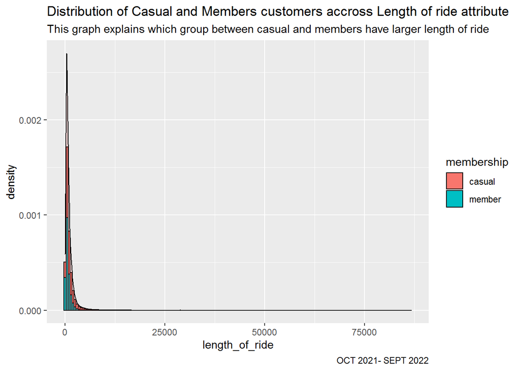

```r
clean_data %>%
  ggplot(mapping=aes(x=length_of_ride )) +geom_histogram(aes(y=..density..,fill=membership),binwidth = 500,color="black")+
  geom_density(alpha=.2,fill="#FF6666")+
  labs(title="Distribution of Casual and Members customers accross Length of ride attribute ",
       subtitle="This graph explains which group between casual and members have larger length of ride",
       caption="OCT 2021- SEPT 2022")
```

### ride_distance

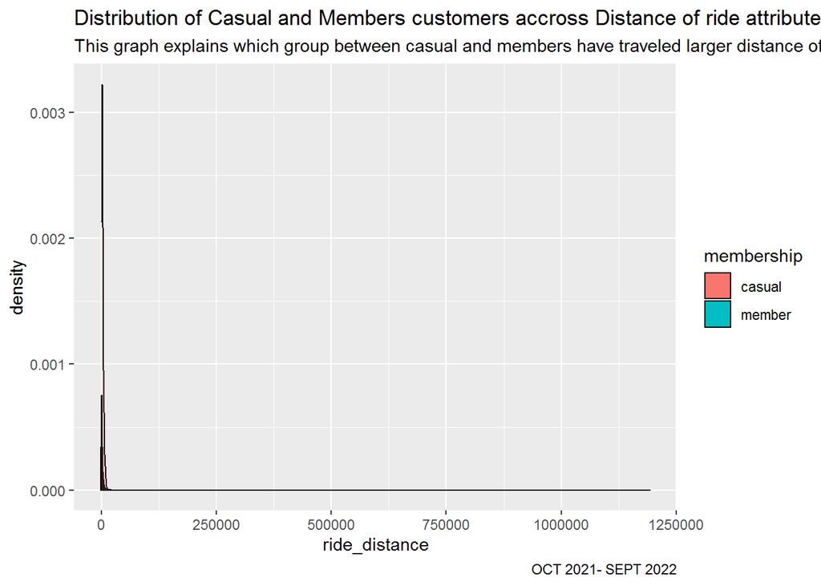

```r
clean_data %>%
  ggplot(mapping=aes(x=ride_distance))+geom_histogram(aes(y=..density..,fill=membership),binwidth = 500,color="black")+
  geom_density(alpha=.2,fill="#FF6666")+
  labs(title="Distribution of Casual and Members customers accross Distance of ride attribute ",
       subtitle="This graph explains which group between casual and members have traveled larger distance of ride",
       caption="OCT 2021- SEPT 2022")
```

## Bivariate analysis

### For arranging, we need to input the levels for months, days as our analysis results will be arranged by months and days

```r
  table(clean_data$day_of_week)
```

```
##
##    Friday    Monday  Saturday    Sunday  Thursday   Tuesday Wednesday
##    817250    766190    962735    840621    836173    813744    839545
```

```r
  clean_data$day_of_week <-
    ordered(clean_data$day_of_week, levels = c('Monday', 'Tuesday', 'Wednesday', 'Thursday', 'Friday', 'Saturday', 'Sunday'))
```

### For analysing number of rides through each day of week in a summary for both casual riders and members

```
## # A tibble: 14 x 3
##    membership day_of_week number_of_ride
##    <chr>      <ord>                <int>
##  1 casual     Monday              291499
##  2 member     Monday              474691
##  3 casual     Tuesday             277404
##  4 member     Tuesday             536340
##  5 casual     Wednesday           292673
##  6 member     Wednesday           546872
##  7 casual     Thursday            310845
##  8 member     Thursday            525328
##  9 casual     Friday              345217
## 10 member     Friday              472033
## 11 casual     Saturday            508856
## 12 member     Saturday            453879
## 13 casual     Sunday              436277
## 14 member     Sunday              404344
```

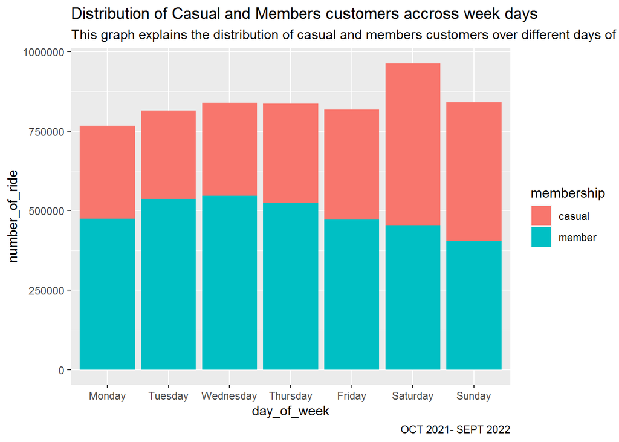

```r
  clean_data %>%
    group_by(membership, day_of_week) %>%
    summarise(number_of_ride = n(), .groups = 'drop') %>%
    arrange(day_of_week)%>%
    print(n=30) %>%
    ggplot()+geom_col(mapping = aes(x=day_of_week,y=number_of_ride,fill=membership))+
    labs(title="Distribution of Casual and Members customers accross week days ",
         subtitle="This graph explains the distribution of casual and members customers over different days of the week",caption="OCT 2021- SEPT 2022")
```

```r
  clean_data$month <-
    ordered(clean_data$month, levels = c('12', '01', '02', '03', '04', '05', '06', '07', '08', '09', '10', '11'))
```

### For analysing number of rides for every month in a summary for both casual riders and members

```
## # A tibble: 24 x 3
##    membership month number_of_ride
##    <chr>      <ord>          <int>
##  1 casual     12             69567
##  2 member     12            177767
##  3 casual     01             18441
##  4 member     01             85217
##  5 casual     02             21345
##  6 member     02             94166
##  7 casual     03             89594
##  8 member     03            194115
##  9 casual     04            126091
## 10 member     04            244794
## 11 casual     05            279722
## 12 member     05            354347
## 13 casual     06            368049
## 14 member     06            400020
## 15 casual     07            405125
## 16 member     07            417320
## 17 casual     08            358121
## 18 member     08            426880
## 19 casual     09            363314
## 20 member     09            392026
## 21 casual     10            256699
## 22 member     10            373880
## 23 casual     11            106703
## 24 member     11            252955
```

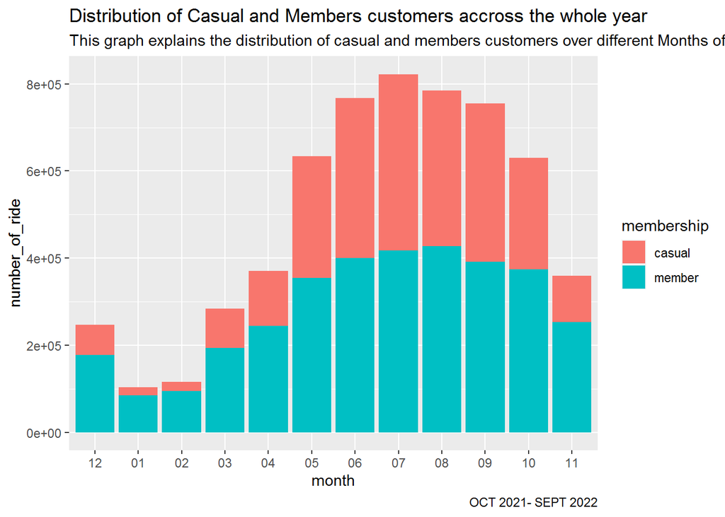

```r
  clean_data %>%
    group_by(membership, month) %>%
    summarise(number_of_ride = n(), .groups = 'drop') %>%
    arrange(month) %>%
    print(n=30) %>%
    ggplot()+geom_col(mapping = aes(x=month,y=number_of_ride,fill=membership))+
    labs(title="Distribution of Casual and Members customers accross the whole year ",
         subtitle="This graph explains the distribution of casual and members customers over different Months of the year",caption="OCT 2021- SEPT 2022")
```

### Aggregating for length of ride, for each week for both casual riders and members

```r
  aggregate(clean_data$length_of_ride ~ clean_data$membership + clean_data$day_of_week, FUN=mean)
```

```
##    clean_data$membership clean_data$day_of_week clean_data$length_of_ride
## 1                 casual                 Monday                 1418.7479
## 2                 member                 Monday                  731.5204
## 3                 casual                Tuesday                 1223.8044
## 4                 member                Tuesday                  714.5201
## 5                 casual              Wednesday                 1189.1278
## 6                 member              Wednesday                  718.3682
## 7                 casual               Thursday                 1223.8644
## 8                 member               Thursday                  724.7478
## 9                 casual                 Friday                 1289.8356
## 10                member                 Friday                  739.5302
## 11                casual               Saturday                 1533.7400
## 12                member               Saturday                  840.4536
## 13                casual                 Sunday                 1594.6738
## 14                member                 Sunday                  841.6602
```

```
## # A tibble: 24 x 3
##    membership month average_ride_length
##    <chr>      <ord>               <dbl>
##  1 casual     12                  1089.
##  2 member     12                   649.
##  3 casual     01                  1035.
##  4 member     01                   695.
##  5 casual     02                  1173.
##  6 member     02                   662.
##  7 casual     03                  1442.
##  8 member     03                   701.
##  9 casual     04                  1389.
## 10 member     04                   680.
## 11 casual     05                  1526.
## 12 member     05                   783.
## 13 casual     06                  1399.
## 14 member     06                   819.
## 15 casual     07                  1386.
## 16 member     07                   805.
## 17 casual     08                  1282.
## 18 member     08                   785.
## 19 casual     09                  1508.
## 20 member     09                   809.
## 21 casual     10                  1363.
## 22 member     10                   734.
## 23 casual     11                  1112.
## 24 member     11                   664.
```

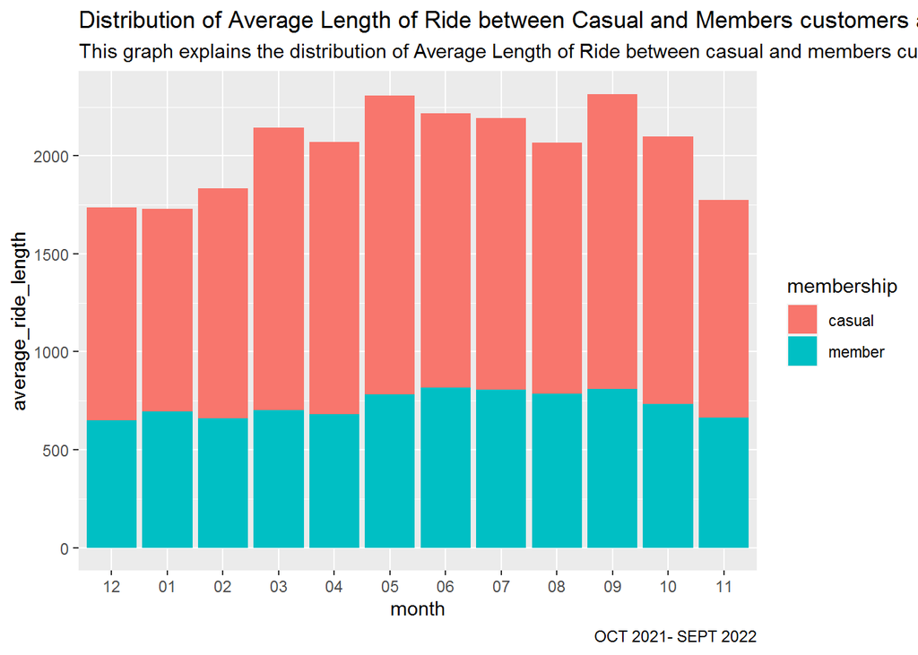

```r
  clean_data %>%
    group_by(membership, month) %>%
    summarise(average_ride_length = mean(length_of_ride), .groups = 'drop') %>%
    arrange(month)%>%
    print(n=30) %>%
    ggplot()+geom_col(mapping = aes(x=month,y=average_ride_length,fill=membership))+
    labs(title="Distribution of Average Length of Ride between Casual and Members customers accross months ",
         subtitle="This graph explains the distribution of Average Length of Ride between casual and members customers over different Months",caption="OCT 2021- SEPT 2022")
```

### For analysing Average ride distance through each day of week in a summary for both casual riders and members

```
## # A tibble: 14 x 3
##    membership day_of_week distance_of_ride
##    <chr>      <ord>                  <dbl>
##  1 casual     Monday                 2159.
##  2 member     Monday                 2050.
##  3 casual     Tuesday                2158.
##  4 member     Tuesday                2059.
##  5 casual     Wednesday              2170.
##  6 member     Wednesday              2078.
##  7 casual     Thursday               2198.
##  8 member     Thursday               2078.
##  9 casual     Friday                 2208.
## 10 member     Friday                 2056.
## 11 casual     Saturday               2345.
## 12 member     Saturday               2194.
## 13 casual     Sunday                 2306.
## 14 member     Sunday                 2161.
```

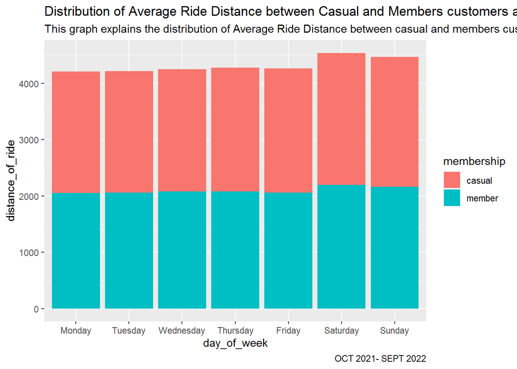

```r
  clean_data %>%
    group_by(membership, day_of_week) %>%
    summarise(distance_of_ride = mean(ride_distance), .groups = 'drop') %>%
    arrange(day_of_week)%>%
    print(n=30) %>%
    ggplot()+geom_col(mapping = aes(x=day_of_week,y=distance_of_ride,fill=membership))+
  labs(title="Distribution of Average Ride Distance between Casual and Members customers accross week ",
         subtitle="This graph explains the distribution of Average Ride Distance between casual and members customers over different Week Days",caption="OCT 2021- SEPT 2022")
```

##for analysing Average ride distance for each month in a summary for both casual riders and members

```
## # A tibble: 24 x 3
##    membership month distance_of_ride
##    <chr>      <ord>            <dbl>
##  1 casual     12               2016.
##  2 member     12               1879.
##  3 casual     01               1930.
##  4 member     01               1746.
##  5 casual     02               1983.
##  6 member     02               1777.
##  7 casual     03               2184.
##  8 member     03               1980.
##  9 casual     04               2217.
## 10 member     04               1947.
## 11 casual     05               2258.
## 12 member     05               2145.
## 13 casual     06               2244.
## 14 member     06               2249.
## 15 casual     07               2219.
## 16 member     07               2259.
## 17 casual     08               2204.
## 18 member     08               2223.
## 19 casual     09               2368.
## 20 member     09               2182.
## 21 casual     10               2278.
## 22 member     10               2018.
## 23 casual     11               2098.
## 24 member     11               1870.
```

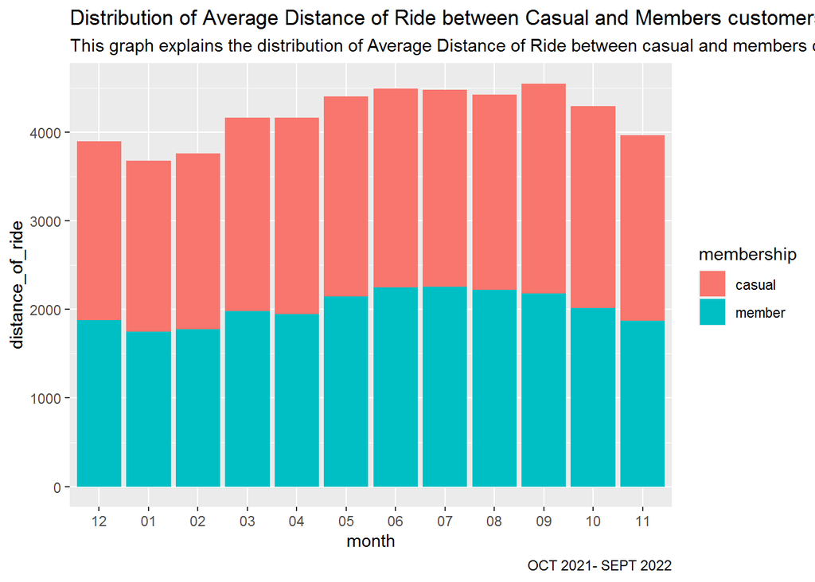

```r
  clean_data %>%
    group_by(membership, month) %>%
    summarise(distance_of_ride = mean(ride_distance), .groups = 'drop') %>%
    arrange(month)%>%
    print(n=30) %>%
    ggplot()+geom_col(mapping = aes(x=month,y=distance_of_ride,fill=membership)) +
    labs(title="Distribution of Average Distance of Ride between Casual and Members customers accross the whole year. ",
         subtitle="This graph explains the distribution of Average Distance of Ride between casual and members customers over different Months",caption="OCT 2021- SEPT 2022")
```